# Structure Equation Modeling

ChatGPT 4o

2025-01-21

## 1 起源

结构方程模型（Structural Equation Modeling, SEM）是一种综合性统计分析方法，用于分析多个变量之间的复杂关系。SEM的起源可以追溯到20世纪50年代，由统计学家和心理学家将回归分析、路径分析和因子分析相结合发展而成。赖特（Sewall Wright）和卡尔·皮尔逊（Karl Pearson）等人的工作奠定了SEM的理论基础。SEM广泛应用于社会科学、心理学、教育学和市场研究等领域，用于验证理论模型和复杂因果关系。

## 2 原理

结构方程模型是一种结合路径分析和确认性因子分析的统计方法，其核心是通过构建潜在变量和观测变量之间的关系，来验证预设的理论模型。SEM由测量模型和结构模型两部分组成：

- **测量模型（Measurement Model）**：描述潜在变量与观测变量之间的关系，类似于确认性因子分析，测量变量被用来衡量潜在变量。
- **结构模型（Structural Model）**：描述潜在变量之间的关系，用路径图表示多个潜在变量之间的因果关系。

SEM使用协方差矩阵，通过最大似然估计等方法估计模型参数，并通过拟合度指标评估模型与数据的匹配程度。SEM的路径系数能够量化变量之间的直接和间接影响。

## 3 适用范围

结构方程模型适用于以下情况：

- **复杂因果模型的验证**：当研究者希望验证多个变量之间的复杂因果关系时，SEM非常适合。
- **潜在变量的使用**：SEM可以处理无法直接观测的潜在变量，适用于对测量误差控制要求较高的场景。
- **测量模型与结构模型结合**：SEM能够同时估计测量模型和结构模型，非常适用于那些包含观测和潜在变量的理论验证。

## 4 应用情境

结构方程模型在多个领域都有广泛的应用，例如：

- **心理学**：用于验证人格、态度和行为之间的复杂因果关系，评估心理测量工具的结构效度。
- **教育学**：分析学习动机、教学方式和学业成绩之间的关系，探索教育干预的影响机制。
- **市场营销**：研究客户满意度、品牌忠诚度和购买意愿之间的因果关系，帮助企业制定营销策略。
- **医学研究**：用于研究健康行为、生活方式与健康结果之间的关系，探索多重健康因素的交互作用。

## 5 优缺点

### 优点

- **处理复杂模型**：SEM可以处理包含多个自变量和因变量的复杂模型，包括直接和间接效应。
- **包含潜在变量**：SEM可以处理潜在变量，能够有效控制测量误差，提高模型的可靠性。
- **综合性强**：SEM结合了因子分析和路径分析，能够同时估计测量误差和因果关系。

### 缺点

- **对样本量要求高**：SEM通常需要较大的样本量来保证模型估计的稳定性和拟合结果的可靠性。
- **对模型假设敏感**：SEM对数据的正态性、线性关系和协方差结构有较高的假设要求，若这些假设不成立，模型结果可能不可靠。
- **模型复杂，解释难度大**：由于SEM模型包含多个潜在变量和路径，模型结果的解释可能比较复杂，尤其是在涉及多个间接效应时。

## 6 在R中的实现及结果解释

在R中，可以使用`lavaan`包中的`sem()`函数进行结构方程模型的分析。以下是一个实现SEM的示例：

```r
# 加载必要的包
library(lavaan)
```

```r
library(ggplot2)

# 示例数据：生成假设数据
set.seed(123)
data <- data.frame(
  V1 = rnorm(100, mean = 5, sd = 2),
  V2 = rnorm(100, mean = 3, sd = 1),
  V3 = rnorm(100, mean = 4, sd = 1.5),
  V4 = rnorm(100, mean = 6, sd = 2)
)

# 定义SEM模型
model <- '
  # 测量模型
  F1 =~ V1 + V2 + V3
  F2 =~ V3 + V4

  # 结构模型
  F2 ~ F1
'

# 进行结构方程模型分析
fit <- sem(model, data = data)
# 输出SEM结果
summary(fit, fit.measures = TRUE)
```

```
## lavaan 0.6-19 ended normally after 54 iterations
##
##   Estimator                                         ML
##   Optimization method                           NLMINB
##   Number of model parameters                        10
##
##   Number of observations                           100
##
## Model Test User Model:
##
##   Test statistic                                 0.090
##   Degrees of freedom                                 0
##
## Model Test Baseline Model:
##
##   Test statistic                                 2.629
##   Degrees of freedom                                 6
##   P-value                                        0.854
##
## User Model versus Baseline Model:
##
##   Comparative Fit Index (CFI)                    0.000
##   Tucker-Lewis Index (TLI)                       1.000
##
## Loglikelihood and Information Criteria:
##
##   Loglikelihood user model (H0)               -729.656
##   Loglikelihood unrestricted model (H1)       -729.610
##
##   Akaike (AIC)                                1479.311
##   Bayesian (BIC)                              1505.363
##   Sample-size adjusted Bayesian (SABIC)       1473.780
##
## Root Mean Square Error of Approximation:
##
##   RMSEA                                          0.000
##   90 Percent confidence interval - lower         0.000
##   90 Percent confidence interval - upper         0.000
##   P-value H_0: RMSEA <= 0.050                       NA
##   P-value H_0: RMSEA >= 0.080                       NA
```

[output cut: 19 more lines]

```
##     V4               -0.747       NA
##
## Regressions:
##                    Estimate  Std.Err  z-value  P(>|z|)
##   F2 ~
##     F1                0.537       NA
##
## Variances:
##                    Estimate  Std.Err  z-value  P(>|z|)
##    .V1                2.815       NA
##    .V2                0.910       NA
##    .V3                1.444       NA
##    .V4                4.000       NA
##     F1                0.485       NA
##    .F2                0.350       NA
```

```r
str(fit)
```

[output not shown]

[output cut: 639 more lines]

[output not shown]

### 结果的可视化

可以使用`semPlot`包中的`semPaths()`函数对SEM的结果进行可视化，直观展示结构模型和测量模型。

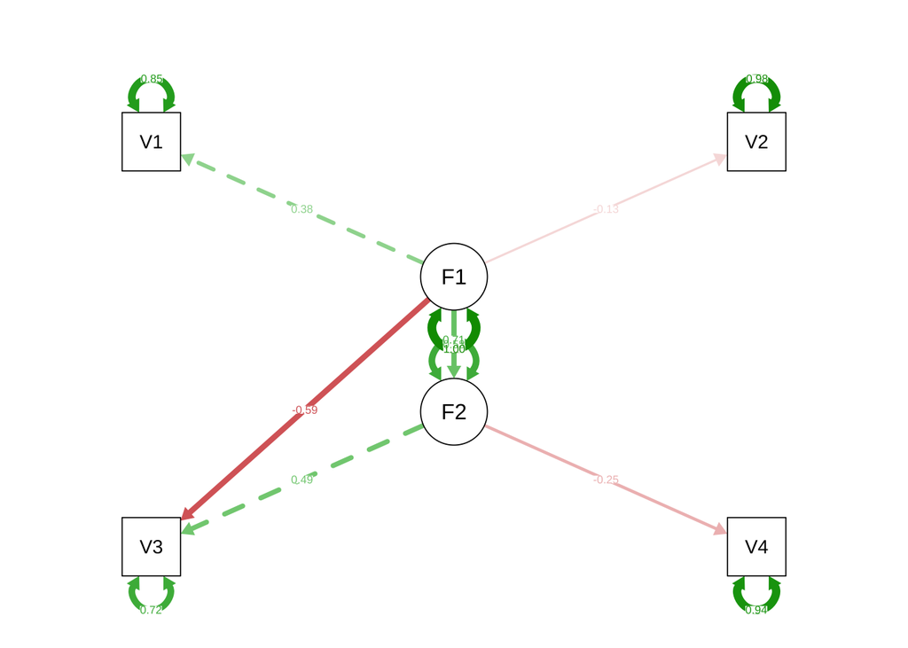

```r
# 安装并加载semPlot包
if (!requireNamespace("semPlot", quietly = TRUE)) {
  install.packages("semPlot")
}
library(semPlot)

# 绘制结构方程模型的路径图
semPaths(fit, what = "std", layout = "tree", title = TRUE, nCharNodes = 0, sizeMan = 7, sizeInt = 5)
```

上述代码将生成SEM的路径图，展示潜在变量与观测变量之间的关系以及潜在变量之间的因果路径，使得模型的解释更加直观。

## 7 小结

- 结构方程模型是一种用于分析多个变量之间复杂关系的统计方法，结合了路径分析和因子分析。
- 适用于处理复杂因果关系和潜在变量的场景，广泛应用于心理学、教育学、市场营销和医学研究等领域。
- 具有处理复杂模型、包含潜在变量的优点，但对样本量和模型假设要求较高，且模型解释难度较大。
- 可以通过R中的`sem()`函数实现结构方程模型分析，并结合可视化工具直观展示模型结果。
- SEM是一种重要的工具，有助于理解多变量之间的复杂因果关系，并能控制测量误差，提高研究的科学性。